# Analysis of Data from Aaron Rising (Pig something?)

Data from Aaron Rising.

Two different excel files (Cobra and Eel). Different animals perhaps?

Aaron told me to take the ‘first tab’ in each excel file. Which is not the case, as at least to me, ‘Sheet 1’ is empty in both. So I’m using the next tab in both, which is ‘Normalized 2 Base For Comb’

# Load data and look at structure (str)

```r
library(tidyverse)
library(ggsci)
cobra <- readxl::read_xls('Cobra 749--_Normalized_Data_.xls', sheet = 'Normalized 2 Base For Comb')
cobra %>% str()
```

```
Classes ‘tbl_df’, ‘tbl’ and 'data.frame':   187 obs. of  8 variables:
 $ Pig_Name  : chr  "Cobra 749" "Cobra 749" "Cobra 749" "Cobra 749" ...
 $ Week      : num  0 0 0 0 0 0 0 0 0 0 ...
 $ Region    : chr  "Healthy_Implant" "Healthy_Implant" "Healthy_Implant" "Healthy_Implant" ...
 $ Cells     : logi  FALSE FALSE FALSE FALSE FALSE FALSE ...
 $ Output    : chr  "Area-Under-Curve" "HFC-Scalar" "LFC-Scalar" "N1" ...
 $ GroupCount: num  3 3 3 3 3 3 3 3 3 3 ...
 $ Data      : num  1 1 1 1 15.7 ...
 $ STD       : num  0.0994 0.3493 0.2259 0.1063 0.5774 ...
```

```r
eel <- readxl::read_xls('Eel 668--_Normalized_Data_.xls', sheet = 'Normalized 2 Base For Comb')
eel %>% str()
```

```
Classes ‘tbl_df’, ‘tbl’ and 'data.frame':   192 obs. of  8 variables:
 $ Pig_Name  : chr  "Eel 668" "Eel 668" "Eel 668" "Eel 668" ...
 $ Week      : num  0 0 0 0 0 0 0 0 0 0 ...
 $ Region    : chr  "Healthy_Sham" "Healthy_Sham" "Healthy_Sham" "Healthy_Sham" ...
 $ Cells     : logi  FALSE FALSE FALSE FALSE FALSE FALSE ...
 $ Output    : chr  "Area-Under-Curve" "HFC-Scalar" "LFC-Scalar" "N1" ...
 $ GroupCount: num  3 3 3 3 3 3 3 3 3 3 ...
 $ Data      : num  1 1 1 1 20.7 ...
 $ STD       : num  0.0537 0.5141 0.1355 0.0631 0.5774 ...
```

# Head (first few lines)

```r
cobra %>% head()
eel %>% head()
```

[output not shown]

Looks like we have implant (cobra) vs sham (eel)?

We have several types of `Output` (Area-Under-Curve, HFC-Scalar, LFC-Scalar, N1, N1-Latency, N1-Prom, N1-Width, N1P1, N2, N2-Latency, N2-Prom, N2-Width, N2P2, P1, P1-Latency, P1-Prom, P1-Width, P1N2, P2, P2-Latency, P2-Prom, P2-Width, Pos.-Area-Under-Curve, RMS-HFC) which are different variables that have been measured. I asked Aaron what he cared most about and he suggested AUC, N1P1, and Latency

# AUC, N1P1, Latency

We need to get the exact names for those variables

We can extract all of the `Output` values and only print the unique ones

```r
eel$Output %>% unique()
```

[output not shown]

OK, so `Area-Under-Curve`, `N1P1`, and `N1-Latency` are the three variables we’ll take a look at. Or fewer if I get confused.

Let’s start by just looking at AUC. Generically it is a machine learning measure of how often an algorithm will pick distinguish the right answer over the wrong one. 1 is perfect. 0 is perfect wrong. 0.5 is a monkey flipping coins. Not sure what it means here, but that isn’t a deal killer yet.

# Summary of eel and cobra AUC

Get the summary data from just the AUC values for each pig

```r
cobra %>% filter(Output == 'Area-Under-Curve') %>% pull(Data) %>% summary()
eel %>% filter(Output == 'Area-Under-Curve') %>% pull(Data) %>% summary()
```

[output not shown]

# What kind of time points or conditions or whatever do we have again?

```r
cobra %>% filter(Output == 'Area-Under-Curve')
```

[output not shown]

Oh, we have *two kinds or regions*. Didn’t see that before. So the above summary doesn’t take that into account.

# Summary by pig and region

```r
cobra %>% filter(Output == 'Area-Under-Curve') %>% group_by(Region) %>% summarise(mean = mean(Data), median= median(Data))
eel %>% filter(Output == 'Area-Under-Curve') %>% group_by(Region) %>% summarise(mean = mean(Data), median= median(Data))
```

[output not shown]

We also have time (Week)

# Plot AUC by time and region and pig

x axis is time, y axis is AUC, and split by region/pig

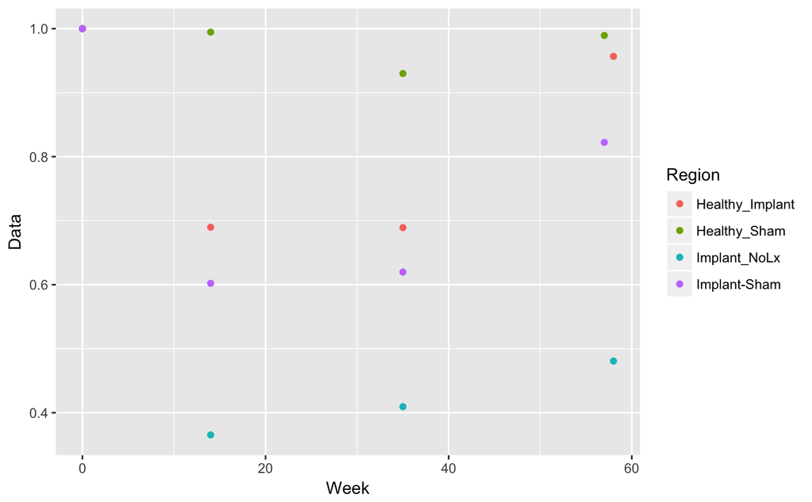